# Item pool

Piotr Król

23 08 2021

Content:

- Preliminary simulation with Kachergis et al. (2021) settings
- Items preselection (2 ways)
- Simulations with the restricted pools

```r
library(mirt)
library(mirtCAT)
library(parallel)
library(plyr)
library(ggpubr)
library(CTT)
```

Prepare data:

```r
responses_demo <- read.csv("Data/responses_demo.csv", encoding = "UTF-8")
responses <- as.matrix(responses_demo[,5:ncol(responses_demo)])
cdi <- read.csv("Data/cdi.csv", encoding = "UTF-8")
load("Data/mod_r")
load("Data/items_to_remove")
responses <- responses[, -items_to_remove]
responses_demo <- responses_demo[, -items_to_remove]
cdi <- cdi[!cdi$number.ws %in% items_to_remove, ]
source(paste0(getwd(),"/get_sim_results.R"))
```

# Preliminary CAT simulation

Preliminary CAT simulation performed with Kachergis et al. (2021) recommended settings:

```r
mod_r #667 items model
```

```
##
## Call:
## mirt(data = responses[, -c(392, 417, 652)], model = 1, SE = TRUE,
##     quadpts = 601, technical = list(NCYCLES = 10000))
##
## Full-information item factor analysis with 1 factor(s).
## Converged within 1e-04 tolerance after 2700 EM iterations.
## mirt version: 1.34
## M-step optimizer: BFGS
## EM acceleration: Ramsay
## Number of rectangular quadrature: 601
## Latent density type: Gaussian
##
## Information matrix estimated with method: Oakes
## Second-order test: model is a possible local maximum
## Condition number of information matrix =  2311.374
##
## Log-likelihood = -460055
## Estimated parameters: 1334
## AIC = 922778.1; AICc = 926480.5
## BIC = 930434.4; SABIC = 926196
## G2 (9999998666) = 885020.2, p = 1
## RMSEA = 0, CFI = NaN, TLI = NaN
```

Prepare items parameters and ability estimations from the full CDI:

```r
params <- as.data.frame(coef(mod_r, simplify = T)$items)[1:2]
fscores <- as.data.frame(fscores(mod_r, method = "MAP", full.scores.SE = T))
save(params, file = "Data/params")
save(fscores, file = "Data/fscores")
```

Make preliminary CAT simulation:

```r
cl <- makeCluster(detectCores())
preliminary_CAT <- mirtCAT(mo = generate.mirt_object(params, '2PL') , method = "MAP", criteria = "MI", start_item = "MI", local_pattern = responses, cl = cl, design = list(min_SEM = 0.15, min_items = 25, max_items = 50))
```

```r
get_sim_results(preliminary_CAT, fscores, params)
```

```
## [1] "Mean length: 29.6  Median length: 25  Correlation: 0.982  Mean SE: 0.121  Reliability: 0.985  Unused items: 428"
```

# First way of items preselection

Calculate correlation of responses with age, difficulty, discrimination and distance from (0,0):

```r
ctt_analysis <- itemAnalysis(responses)
cor <- apply(responses, 2, FUN = function(x) cor(x, responses_demo$months))
ctt_params <- data.frame(dffclt = ctt_analysis$itemReport$itemMean, dscrmn = ctt_analysis$itemReport$pBis, cor = cor)
ctt_params$dist <- sqrt(ctt_params$dscrmn^2 + ctt_params$cor^2)
ctt_params <- cbind(ctt_params, cdi)
```

```r
head(ctt_params)
```

```
##          dffclt    dscrmn       cor      dist    category number.ws number.wg
## item1 0.5781454 0.4460846 0.2360508 0.5046894 Z01.odgłosy         1         1
## item2 0.9068350 0.2628640 0.1217888 0.2897068 Z01.odgłosy         2         2
## item3 0.8463213 0.3083515 0.1430733 0.3399273 Z01.odgłosy         3         3
## item4 0.7470614 0.4439564 0.2488537 0.5089455 Z01.odgłosy         4         4
## item5 0.8959512 0.2919193 0.1744753 0.3400860 Z01.odgłosy         5         5
## item6 0.7818894 0.3856960 0.2060606 0.4372898 Z01.odgłosy         6         6
##       position
## item1    gę.gę
## item2  hau.hau
## item3 ko.ko.ko
## item4  kwa.kwa
## item5     miau
## item6  mee.bee
```

Select best 250 items and visualize:

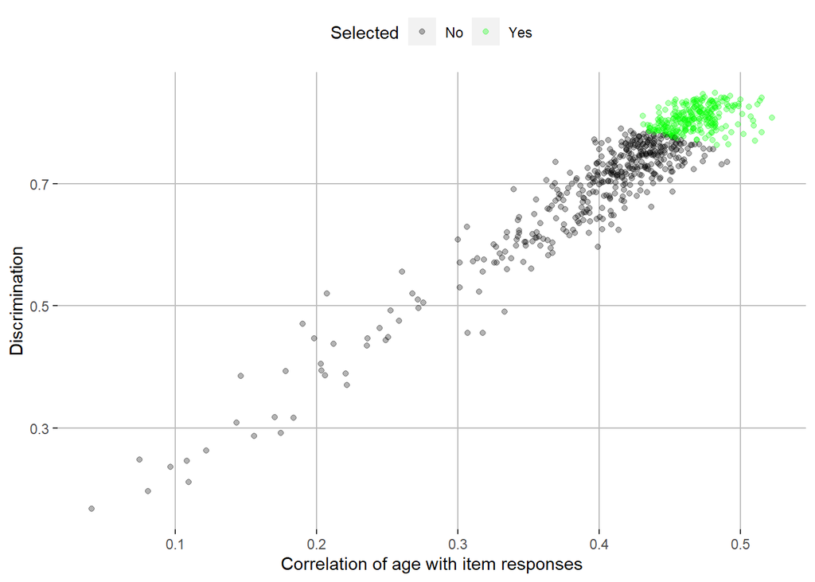

```r
ctt_params_s <- ctt_params
ctt_params_s[ctt_params_s$number.ws %in% ctt_params[order(ctt_params$dist, decreasing = T), ][1:250, "number.ws"], "selected"] <- "Yes"
ctt_params_s[is.na(ctt_params_s$selected), "selected"] <- "No"

ggplot(ctt_params_s, aes(cor, dscrmn, colour=selected, label=position)) +
  geom_point(alpha = 0.3) +
  xlab("Correlation of age with item responses") +
  ylab("Discrimination") +
  labs(colour = "Selected") +
  scale_color_manual(values = c("Black", "Green")) +
  theme(
  panel.background = element_rect(fill = NA),
  panel.grid.major = element_line(colour = "grey"),
  legend.position = "top"
)
```

Check how many of items used in preliminary CAT simulation are in the currently selected 250 items:

```r
table(as.vector(which(apply(laply(preliminary_CAT, function(x) x$raw_responses), 2, function(x) any(!is.na(x))))) %in% ctt_params_s[ctt_params_s$selected == "Yes", "number.ws"] )
```

```
##
## FALSE  TRUE
##   155    84
```

## Simulation with the restricted pool

Create model using only selected items:

```r
mod_r250_1 <- mirt(data = responses[, row.names(ctt_params_s[ctt_params_s$selected == "Yes", ])], model = 1, SE = TRUE)
```

```r
mod_r250_1
```

```
##
## Call:
## mirt(data = responses[, row.names(ctt_params_s[ctt_params_s$selected ==
##     "Yes", ])], model = 1, SE = TRUE)
##
## Full-information item factor analysis with 1 factor(s).
## Converged within 1e-04 tolerance after 238 EM iterations.
## mirt version: 1.34
## M-step optimizer: BFGS
## EM acceleration: Ramsay
## Number of rectangular quadrature: 61
## Latent density type: Gaussian
##
## Information matrix estimated with method: Oakes
## Second-order test: model is a possible local maximum
## Condition number of information matrix =  99.24674
##
## Log-likelihood = -149871
## Estimated parameters: 500
## AIC = 300741.9; AICc = 301020.9
## BIC = 303611.6; SABIC = 302023
## G2 (1e+10) = 268836.1, p = 1
## RMSEA = 0, CFI = NaN, TLI = NaN
```

Try increase quadrature points:

```r
mod_r250_2 <- mirt(data = responses[, row.names(ctt_params_s[ctt_params_s$selected == "Yes", ])], model = 1, SE = TRUE, quadpts = 101)
```

```r
mod_r250_2
```

```
##
## Call:
## mirt(data = responses[, row.names(ctt_params_s[ctt_params_s$selected ==
##     "Yes", ])], model = 1, SE = TRUE, quadpts = 101)
##
## Full-information item factor analysis with 1 factor(s).
## Converged within 1e-04 tolerance after 346 EM iterations.
## mirt version: 1.34
## M-step optimizer: BFGS
## EM acceleration: Ramsay
## Number of rectangular quadrature: 101
## Latent density type: Gaussian
##
## Information matrix estimated with method: Oakes
## Second-order test: model is a possible local maximum
## Condition number of information matrix =  170.2831
##
## Log-likelihood = -149603
## Estimated parameters: 500
## AIC = 300206; AICc = 300485
## BIC = 303075.7; SABIC = 301487.1
## G2 (1e+10) = 268300.2, p = 1
## RMSEA = 0, CFI = NaN, TLI = NaN
```

Increase once more:

```r
mod_r250_3 <- mirt(data = responses[, row.names(ctt_params_s[ctt_params_s$selected == "Yes", ])], model = 1, SE = TRUE, quadpts = 151, technical = list(NCYCLES = 10000))
```

```r
mod_r250_3
```

```
##
## Call:
## mirt(data = responses[, row.names(ctt_params_s[ctt_params_s$selected ==
##     "Yes", ])], model = 1, SE = TRUE, quadpts = 151, technical = list(NCYCLES = 10000))
##
## Full-information item factor analysis with 1 factor(s).
## Converged within 1e-04 tolerance after 528 EM iterations.
## mirt version: 1.34
## M-step optimizer: BFGS
## EM acceleration: Ramsay
## Number of rectangular quadrature: 151
## Latent density type: Gaussian
##
## Information matrix estimated with method: Oakes
## Second-order test: model is a possible local maximum
## Condition number of information matrix =  368.1972
##
## Log-likelihood = -149574.8
## Estimated parameters: 500
## AIC = 300149.5; AICc = 300428.5
## BIC = 303019.2; SABIC = 301430.6
## G2 (1e+10) = 268243.7, p = 1
## RMSEA = 0, CFI = NaN, TLI = NaN
```

And once more:

```r
mod_r250_4 <- mirt(data = responses[, row.names(ctt_params_s[ctt_params_s$selected == "Yes", ])], model = 1, SE = TRUE, quadpts = 301, technical = list(NCYCLES = 10000))
```

```r
mod_r250_4
```

```
##
## Call:
## mirt(data = responses[, row.names(ctt_params_s[ctt_params_s$selected ==
##     "Yes", ])], model = 1, SE = TRUE, quadpts = 301, technical = list(NCYCLES = 10000))
##
## Full-information item factor analysis with 1 factor(s).
## Converged within 1e-04 tolerance after 1305 EM iterations.
## mirt version: 1.34
## M-step optimizer: BFGS
## EM acceleration: Ramsay
## Number of rectangular quadrature: 301
## Latent density type: Gaussian
##
## Information matrix estimated with method: Oakes
## Second-order test: model is a possible local maximum
## Condition number of information matrix =  642.0377
##
## Log-likelihood = -149574
## Estimated parameters: 500
## AIC = 300147.9; AICc = 300426.9
## BIC = 303017.6; SABIC = 301429
## G2 (1e+10) = 268242.1, p = 1
## RMSEA = 0, CFI = NaN, TLI = NaN
```

Sice difference in Log-Lik is minimal I select mod_r250_4 for further analysis and cosider 301 quadrature points as optimal number for this number of items.

Check items fit:

```r
itemfit <- itemfit(mod_r250_4 , method = "MAP")
```

```r
length(which(itemfit$p.S_X2 < 0.001))
```

```
## [1] 0
```

Check LD:

```r
residuals <- residuals(mod_r250_4 )
residuals[lower.tri(residuals)] <- NA
```

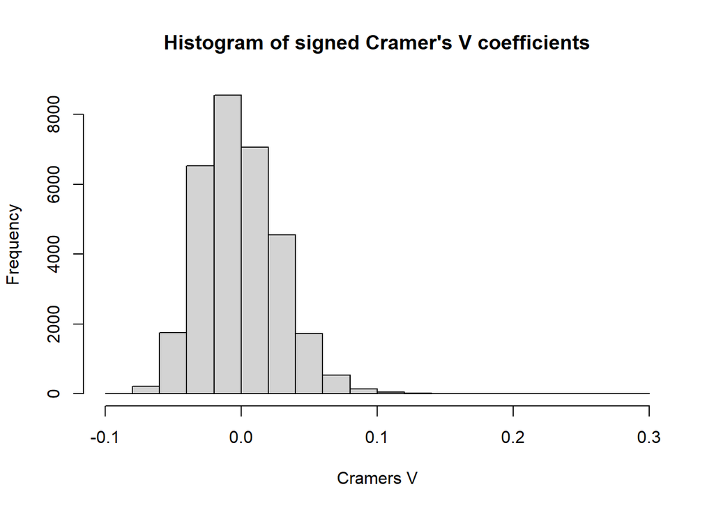

```r
hist(residuals, main="Histogram of signed Cramer's V coefficients", xlab= "Cramers V")
```

```r
summary(as.vector(residuals))
```

```
##    Min. 1st Qu.  Median    Mean 3rd Qu.    Max.    NA's
##  -0.095  -0.022  -0.009  -0.001   0.018   0.282   31375
```

Make simulation with Kachergis et al. (2021) recommended settings on a restricted pool model:

```r
params_r250 <- as.data.frame(coef(mod_r250_4 , simplify = T)$items)[1:2]
preliminary_CAT_r250 <- mirtCAT(mo = generate.mirt_object(params_r250, '2PL'), method = "MAP", criteria = "MI", start_item = "MI", local_pattern = responses[, row.names(ctt_params_s[ctt_params_s$selected == "Yes", ])], cl = cl, design = list(min_SEM = 0.15, min_items = 25, max_items = 50))
```

```r
get_sim_results(preliminary_CAT_r250, fscores, params_r250)
```

```
## [1] "Mean length: 34.5  Median length: 25  Correlation: 0.955  Mean SE: 0.174  Reliability: 0.97  Unused items: 89"
```

## Second way of preselection

Count difficulties in months intervals and calculate theirs correlations with ages:

```r
dffclts_months <- c()
for (month in unique(responses_demo$months)){
  responses <- responses_demo[responses_demo$months == month, ]
  responses <- as.matrix(responses[,5:ncol(responses)])
  ctt_analysis <- itemAnalysis(responses)
  dffclts_months <- rbind(dffclts_months, ctt_analysis$itemReport$itemMean)
}
cor2 <- apply(dffclts_months, 2, FUN = function(x) cor(x, unique(responses_demo$months)))
ctt_params$cor2 <- cor2
ctt_params$dist2 <- sqrt(ctt_params$dscrmn^2 + ctt_params$cor2^2)
```

Select best 250 items and visualize:

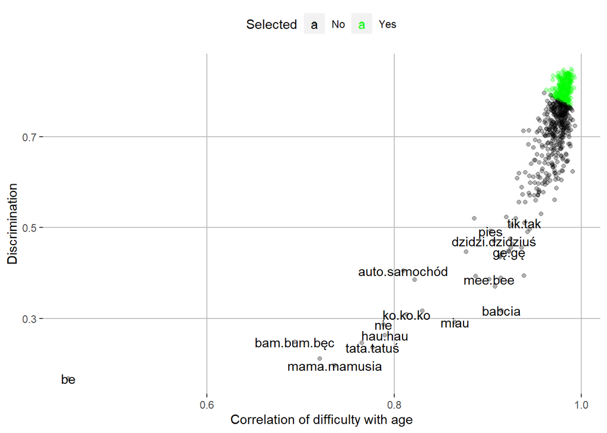

```r
ctt_params_s <- ctt_params
ctt_params_s[ctt_params_s$number.ws %in% ctt_params[order(ctt_params$dist2, decreasing = T), ][1:250, "number.ws"], "selected"] <- "Yes"
ctt_params_s[is.na(ctt_params_s$selected), "selected"] <- "No"

ggplot(ctt_params_s, aes(cor2, dscrmn, colour=selected, label=position)) +
  geom_point(alpha = 0.3) +
  geom_text(aes(label=ifelse(dscrmn < 0.55 & cor2 < 0.95, as.character(position),'')), check_overlap = T) +
  xlab("Correlation of difficulty with age") +
  ylab("Discrimination") +
  labs(colour = "Selected") +
  scale_color_manual(values = c("Black", "Green")) +
  theme(
  panel.background = element_rect(fill = NA),
  panel.grid.major = element_line(colour = "grey"),
  legend.position = "top"
)
```

Check how many of items used in preliminary CAT simulation are in the currently selected 250 items:

```r
table(as.vector(which(apply(laply(preliminary_CAT, function(x) x$raw_responses), 2, function(x) any(!is.na(x))))) %in% ctt_params_s[ctt_params_s$selected == "Yes", "number.ws"] )
```

```
##
## FALSE  TRUE
##   158    81
```

```r
mod_r250_s2 <- mirt(data = responses[, row.names(ctt_params_s[ctt_params_s$selected == "Yes", ])], model = 1, SE = TRUE, quadpts = 301, technical = list(NCYCLES = 10000))
```

Check items fit:

```r
itemfit_s2 <- itemfit(mod_r250_s2 , method = "MAP")
```

```r
length(which(itemfit_s2$p.S_X2 < 0.001))
```

```
## [1] 1
```

```r
misfit <- itemfit_s2[itemfit_s2$p.S_X2 < 0.001, "item"]
misfit_nr <- as.numeric(substr(misfit, 5, 7))
cdi[cdi$number.ws == misfit_nr, ]
```

```
##                           category number.ws number.wg position
## 265 Z09.przedmioty_domowego_użytku       265       183  ręcznik
```

Check LD:

```r
residuals_s2 <- residuals(mod_r250_s2)
residuals_s2[lower.tri(residuals_s2)] <- NA
```

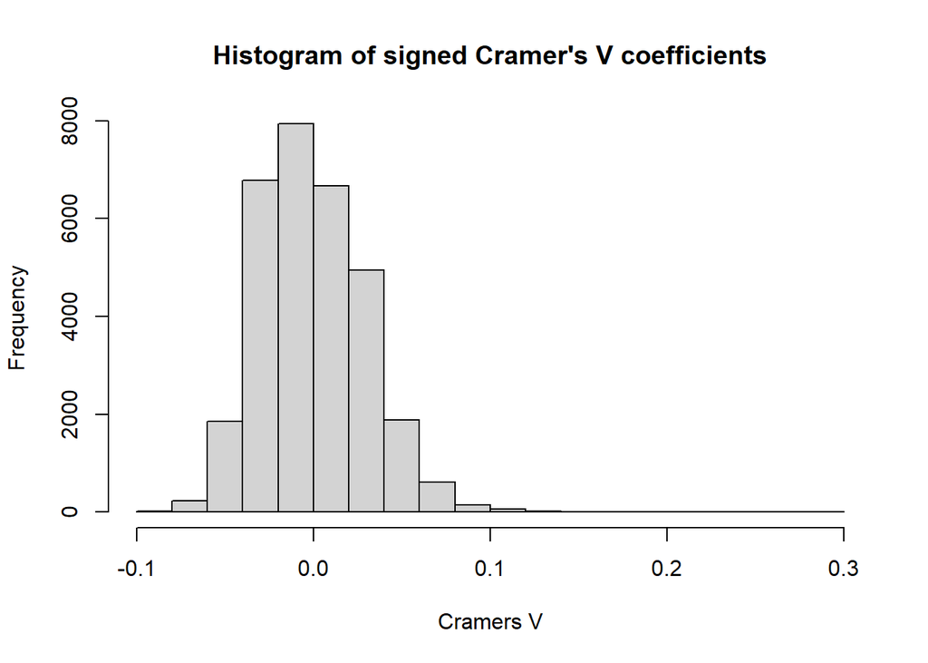

```r
hist(residuals_s2, main="Histogram of signed Cramer's V coefficients", xlab= "Cramers V")
```

```r
summary(as.vector(residuals_s2))
```

```
##    Min. 1st Qu.  Median    Mean 3rd Qu.    Max.    NA's
##  -0.093  -0.022  -0.010  -0.001   0.020   0.285   31375
```

Remove one misfit and create model once more:

```r
responses2 <- responses[, row.names(ctt_params_s[ctt_params_s$selected == "Yes", ])]
responses2 <- responses2[, -c(match(misfit, colnames(responses2)))]
mod_r250_s2_2 <- mirt(data = responses2, model = 1, SE = TRUE, quadpts = 301, technical = list(NCYCLES = 10000))
```

Check items fit:

```r
itemfit_s2_2 <- itemfit(mod_r250_s2_2 , method = "MAP")
```

```r
length(which(itemfit_s2_2$p.S_X2 < 0.001))
```

```
## [1] 0
```

Make simulation with Kachergis et al. (2021) recommended settings on a restricted pool (249 items) model:

```r
params_r250_s2 <- as.data.frame(coef(mod_r250_s2_2 , simplify = T)$items)[1:2]
preliminary_CAT_r250_s2 <- mirtCAT(mo = generate.mirt_object(params_r250_s2, '2PL'), method = "MAP", criteria = "MI", start_item = "MI", local_pattern = responses[, row.names(ctt_params_s[ctt_params_s$selected == "Yes", ])], cl = cl, design = list(min_SEM = 0.15, min_items = 25, max_items = 50))
```

```r
get_sim_results(preliminary_CAT_r250_s2, fscores, params_r250_s2)
```

```
## [1] "Mean length: 36.5  Median length: 27  Correlation: 0.942  Mean SE: 0.194  Reliability: 0.962  Unused items: 92"
```